# Course Diary Chapter 3

## Student Alcohol Consumption and Regression Analysis

Elizabeth Oakes, 17.11.2019

We have a dataset of survey answers from Portuguese high school students. There are 382 observations of 36 variables, as follows.

> colnames(alc) “X” “school” “sex” “age” “address” “famsize” “Pstatus”  
> “Medu” “Fedu” “Mjob” “Fjob” “reason” “nursery” “internet”  
> “guardian” “traveltime” “studytime” “failures” “schoolsup” “famsup” “paid”  
> “activities” “higher” “romantic” “famrel” “freetime” “goout” “Dalc”  
> “Walc” “health” “absences” “G1” “G2” “G3” “alc_use”  
> “high_use”

“X” is a kind of index, “Dalc” weekday alcohol use, “Walc” weekend alcohol use, “G1-3” records grades in math and Portuguese classes, and “high_use” is a logical variable denoting whether a student exceeds a certain level of alcohol consumption.

Let’s view observations of each variable graphically by using the code: gather(alc) %>% ggplot(aes(value)) + facet_wrap(“key”, scales = “free”) + geom_bar()

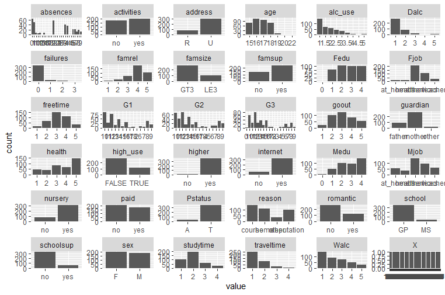

Fig. 1 An overview of each variable.

From this overview, I pick four variables and explore their possible relation to high alcohol use, romantic (student has a romantic relationship), freetime (how much free time does the student have), goout (how often does the student go out with friends), and G3 (student’s final grade in their course - math or Portuguese).

I hypothesize that having a romantic relationship reduces the likelihood of high alcohol consumption because the student will dedicate time to the relationship that might otherwise be spent partying. Free time and going out with friends, however, may increase the likelihood of high alcohol consumption, especially the latter variable. From another angle, what kind of effect does high alcohol consumption have on grades? I don’t think it has the biggest effect on grades, but I’m curious if there is one.

Let’s begin by visualizing the relationship between final course grade and high alcohol use by sex using the folling code.

g1 <- ggplot(alc, aes(x = high_use, y = G3, col = sex)) g1 + geom_boxplot() + ylab(“grade”) + ggtitle(“Student grades by alcohol consumption and sex”)

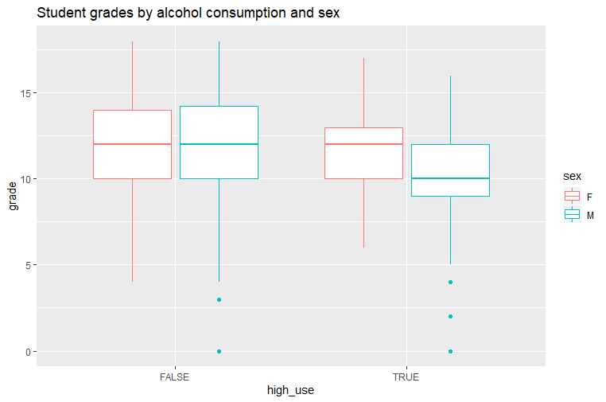

Fig. 2

It appears that the mean grade for female students is not much affected by high alcohol use, but it does correlate with a lowered mean grade for male students.

Is alcohol use affected by going out with friends or having a romantic relationship? Lets visualize those relationships in sequence using the code:

social <- ggplot(alc, aes(x = goout, fill = high_use)) social + geom_bar(position = “dodge”) + ggtitle(“Student alcohol consumption and socializing”)

which yields the bar graph

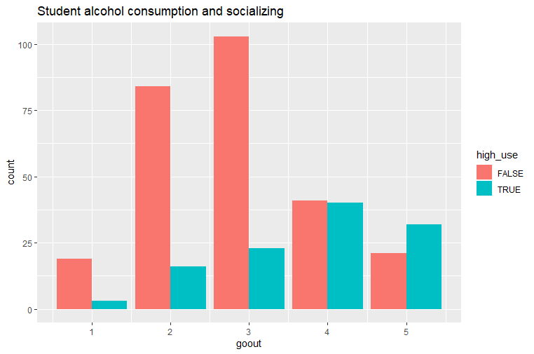

Fig. 3

and the code:

rombar <- ggplot(alc, aes(x = romantic, fill = high_use)) rombar + geom_bar(position = “dodge”) + ggtitle(“Student alcohol consumption and romantic relationship”)

which yields the graph

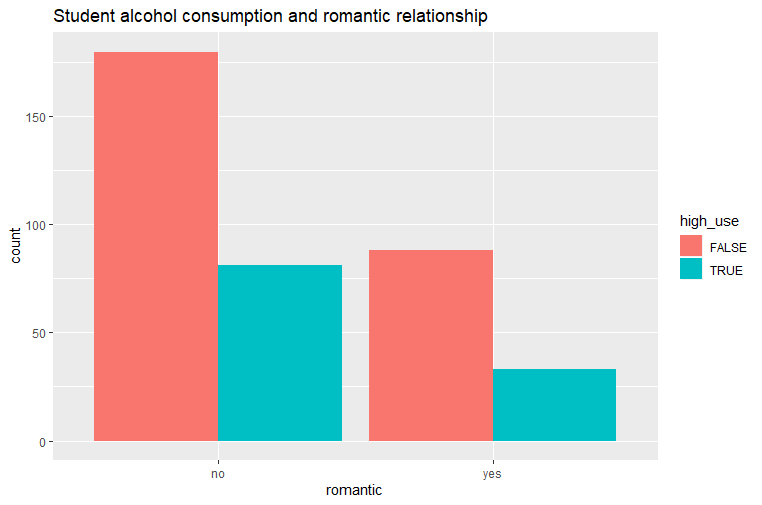

Fig. 4

It does appear that more time spent out with friends correlates with high alcohol use, but romantic relationship status does not appear to effect alcohol use.

Lastly, let’s view free time and high alcohol use in the same way. Using the code:

free <- ggplot(alc, aes(x = freetime, fill = high_use)) free + geom_bar(position = “dodge”) +ggtitle(“Student alcohol consumption and free time”)

to produce the graph:

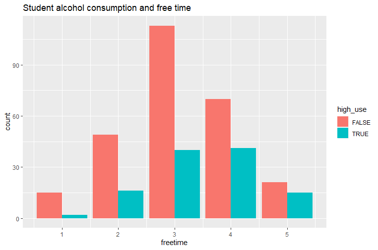

That looks ambiguous. Let’s use the likely variables to make a model and test it out.

I use the following code to make a logistic regression model for high alcohol usage using the variables G3, fac_goout (a factorized version of goout, and sex)

alc <- mutate(alc, fac_goout = as.factor(alc$goout)) levels(alc$fac_goout) m <- glm(high_use ~ G3 + fac_goout + sex, data = alc, family = “binomial”)

Summary gives the following table:

```
        Deviance Residuals:
Min       1Q   Median       3Q      Max
-1.7073  -0.7456  -0.4965   0.8848   2.2365

        Coefficients:
             Estimate Std. Error z value Pr(>|z|)
(Intercept) -1.73379    0.76501  -2.266 0.023430 *
G3          -0.05105    0.03814  -1.338 0.180784
fac_goout2   0.18613    0.68680   0.271 0.786387
fac_goout3   0.31499    0.67068   0.470 0.638599
fac_goout4   1.85873    0.66841   2.781 0.005422 **
fac_goout5   2.15320    0.69166   3.113 0.001851 **
sexM         0.92618    0.25281   3.663 0.000249 ***

Signif. codes:  0 ‘***’ 0.001 ‘**’ 0.01 ‘*’ 0.05 ‘.’ 0.1 ‘ ’ 1
(Dispersion parameter for binomial family taken to be 1)

Null deviance: 465.68  on 381  degrees of freedom
Residual deviance: 392.84  on 375  degrees of freedom
AIC: 406.84

Number of Fisher Scoring iterations: 4
```

I am supposed to interpret this, but I lack the mathematical knowledge, so go ahead and take off some points for that.

The odds ratio of the coefficients gives us the following:

```
                    OR      2.5 %    97.5 %

    (Intercept) 0.1766131 0.03323132  0.711935

    G3          0.9502353 0.88147398  1.024115

    fac_goout2  1.2045757 0.34838015  5.611834

    fac_goout3  1.3702459 0.41293177  6.243272

    fac_goout4  6.4155876 1.95388571 29.193015

    fac_goout5  8.6123470 2.48872304 40.575831

    sexM        2.5248403 1.54695711  4.176828
```

I also can’t interpret this. However, we can look at a simple 2x2 table of the model’s predictions versus the actuality as so:

```
           prediction
  high_use FALSE TRUE
  FALSE   245   23
  TRUE     62   52
```

We can look at the same thing graphically.

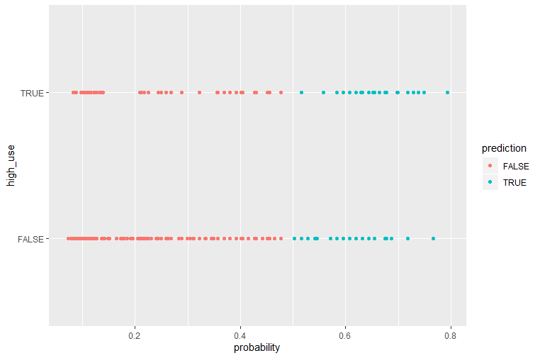

Fig. 5

Of 382 predictions, 297 were correct and 85 false. That’s about 77.75% correct, which looks better than chance.

Surprise, teenagers like to drink with their friends.